## Setting up the contents for the exercise

### Loading packages for easier data wrangling and plotting

For the following steps which include plotting, we are going to use some functions in following packages:

```r
library(GGally)
library(ggpubr)
library(tidyverse)
library(lme4)
```

### Reading in the two data sets

First the `BPRS` dataset which as described in Multivariate Analysis for the Behavioral Sciences text book* contains data of 40 male subjects from two treatment groups which were assessed using brief psychiatric rating scale (BPRS) weekly for 8 weeks.

```r
# reading in
BPRS <- read.table("Data/BPRS.tsv", header = T) %>%
  mutate_at(1:2, as.factor)
# view structure
str(BPRS)
```

```
## 'data.frame':    360 obs. of  5 variables:
##  $ treatment: Factor w/ 2 levels "1","2": 1 1 1 1 1 1 1 1 1 1 ...
##  $ subject  : Factor w/ 20 levels "1","2","3","4",..: 1 2 3 4 5 6 7 8 9 10 ...
##  $ weeks    : chr  "week0" "week0" "week0" "week0" ...
##  $ bprs     : int  42 58 54 55 72 48 71 30 41 57 ...
##  $ week     : int  0 0 0 0 0 0 0 0 0 0 ...
```

Second dataset for this exercise is `RATS` which contains weight information gathered from rats on three different diets over a 9-week period. Measurements were mainly taken on a weekly basis*.

```r
# reading in
RATS <- read.table("Data/RATS.tsv", header = T) %>%
  mutate_at(1:2, as.factor)
# view structure
str(RATS)
```

```
## 'data.frame':    176 obs. of  5 variables:
##  $ ID    : Factor w/ 16 levels "1","2","3","4",..: 1 2 3 4 5 6 7 8 9 10 ...
##  $ Group : Factor w/ 3 levels "1","2","3": 1 1 1 1 1 1 1 1 2 2 ...
##  $ WD    : chr  "WD1" "WD1" "WD1" "WD1" ...
##  $ Weight: int  240 225 245 260 255 260 275 245 410 405 ...
##  $ Time  : int  1 1 1 1 1 1 1 1 1 1 ...
```

**Vehkalahti, Kimmo & Everitt, Brian S. (2019). Multivariate Analysis for the Behavioral Sciences , Second Edition. Chapman and Hall/CRC, Boca Raton, Florida, USA.

## Graphical displays and summary measure approach using RATS data

### General features of the data

Lets start by plotting the longitudal data with and without standardization.

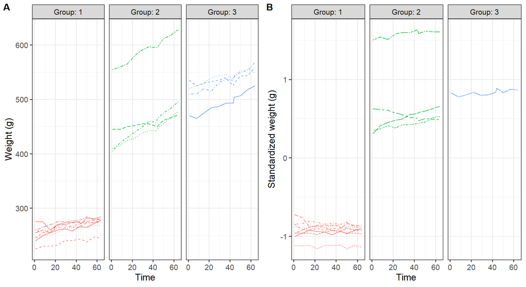

**Figure 1: A)** Weights by days of individual rats separated by groups **B)** Standardized weights by groups of mice

```r
# Draw the plot
p1 <- ggplot(RATS, aes(x = Time, y = Weight, linetype = ID, color=Group)) +
  geom_line() +
  scale_linetype_manual(values = rep(1:16, times=3)) +
  facet_grid(. ~ Group, labeller = label_both) +
  theme(legend.position = "none") +
  scale_y_continuous(limits = c(min(RATS$Weight), max(RATS$Weight))) +
  theme_bw(14) +
  ylab("Weight (g)") +
  theme(legend.position = "none")

RATS.scaled <- RATS %>%
  group_by(Time) %>%
  mutate(std.weigth=(Weight-mean(Weight))/sd(Weight)) %>%
  ungroup()

p2 <- ggplot(RATS.scaled, aes(x = Time, y = std.weigth, linetype = ID, color=Group)) +
  geom_line() +
  facet_grid(. ~ Group, labeller = label_both) +
  theme(legend.position = "none") +
  scale_y_continuous(limits = c(min(RATS.scaled$std.weigth), max(RATS.scaled$std.weigth))) +
  theme_bw(14) +
  ylab("Standardized weight (g)") +
  theme(legend.position = "none")

ggarrange(p1,p2, labels = "AUTO")
```

Based **Figure 1A** we could boldly assume that the rats are gaining weight on the diets (esp. groups 2&3). There seems to be some differences among the weight gain however on different diets. From **Figure 1B** we can see that while there are some instances were “tracking” seems to be evident there are many cases against it also . Also, group two seems to have a quite large specimen compared to the peers!

Lets delve deeper into the data. Making observations based on plots consisting of individuals is of ten misleading so we’ll summarize the data bit.

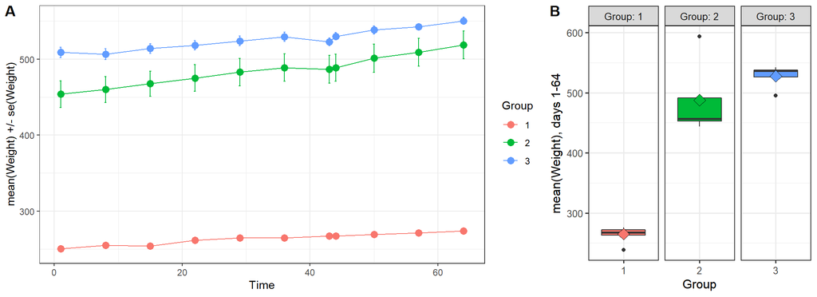

**Figure 2: A)** Group means with standard errors across the time points **B)** Means of individuals off timepoints by group

```r
# Summary data with mean and standard error of bprs by treatment and week
RATS.SE <- RATS %>%
  group_by(Group, Time) %>%
  summarise(mean = mean(Weight), se = sd(Weight)/sqrt(16)) %>% # 16 here is the amount of individuals per groups
  ungroup()

# Plot the mean profiles
p1 <- ggplot(RATS.SE, aes(x = Time, y = mean, colour=Group)) +
  geom_line() +
  geom_point(size=3) +
  geom_errorbar(aes(ymin=mean-se, ymax=mean+se), width=0.3) +
  scale_y_continuous(name = "mean(Weight) +/- se(Weight)") +
  theme_bw()

# Create a summary data by treatment and subject with mean as the summary variable (ignoring baseline week 0).
RATS.scaled.gr <- RATS %>%
  dplyr::filter(Time>1) %>%
  group_by(Group, ID) %>%
  summarise(scaled.mean=mean(Weight)) %>%
  ungroup()

p2 <- ggplot(RATS.scaled.gr, aes(x = Group, y = scaled.mean, fill=Group)) +
  geom_boxplot() +
  facet_grid(.~Group, scales = "free_x", labeller = label_both) +
  stat_summary(fun = "mean", geom = "point", shape=23, size=4) +
  scale_y_continuous(name = "mean(Weight), days 1-64") +
  theme_bw(12) +
  theme(legend.position = "none")

# Combine plots
ggarrange(p1,p2, labels = "AUTO", widths = c(2,1), nrow = 1)
```

### Testing for differences using summary measure approach

```r
# Create a new data by filtering the outlier
RATS.f <- RATS %>%
  dplyr::filter(Weight<550) %>% ## remove the one "outlier"
  filter(Time > 1 ) %>% # remove baseline
  group_by(Group, WD) %>%
  summarise( mean = mean(Weight) )%>%
  ungroup()
```

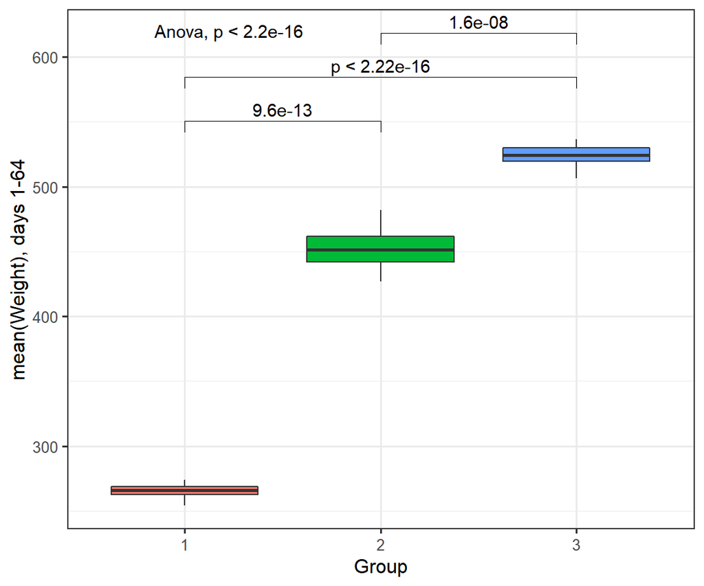

**Figure 3:** Summary approach. P-values for T-test unless annotated differently

```r
comps <- list( c("1", "2"), c("1", "3"), c("2", "3") )

ggplot(RATS.f, aes(x = Group, y = mean, fill=Group)) +
  geom_boxplot() +
  stat_compare_means(method = "t.test", comparisons = comps) +
  stat_compare_means(label.y = 615, method = "anova") +
  scale_y_continuous(name = "mean(Weight), days 1-64") +
  theme_bw(12) +
  theme(legend.position = "none")
```

Every groups between each other and in pairwise comparisons are significantly different it seems

## Linear mixed effects models for BPRS data

### A glimpse into the data set

Lets start by taking a quick look at the data and misleadingly not with `glimpse` (terrible pun(?)) but by plotting BPRS’s of the different subjects band treatments treatments.

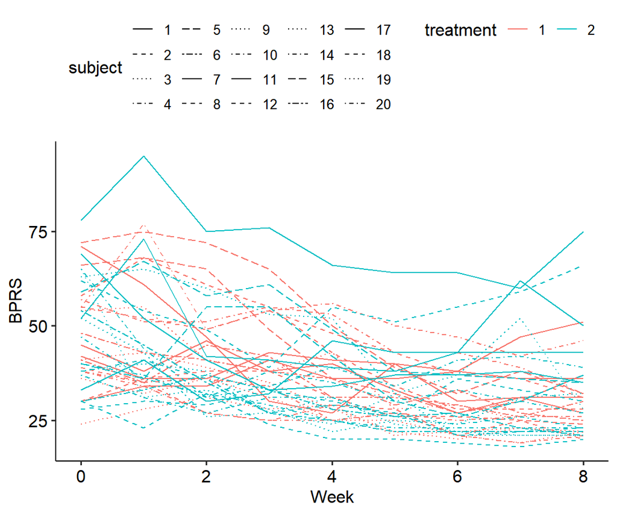

**Figure 4:** Plot of the time series data

```r
# Plot the BPRS data
ggplot(BPRS, aes(x = week, y = bprs, colour = treatment, linetype=subject)) +
  geom_line() +
  scale_linetype_manual(values = rep(1:10, times=4)) +
  scale_x_continuous(name = "Week") +
  scale_y_continuous(name = "BPRS") +
  theme_pubr()
```

From **Figure 4** we can see that there is a general decline in BPR score during the treatment period, but it is quite hard to see whether there are differences between the groups from this plot.

### Fitting linear model

To gain better understanding of how treatment and time relate to BRPS lets fit a linear model using `week` and `treatment` as explanatory variables for `brps`.

```r
# create a regression model RATS_reg
bprs_reg <- lm(bprs ~ week + treatment,BPRS)

# print out a summary of the model
summary(bprs_reg)
```

```
##
## Call:
## lm(formula = bprs ~ week + treatment, data = BPRS)
##
## Residuals:
##     Min      1Q  Median      3Q     Max
## -22.454  -8.965  -3.196   7.002  50.244
##
## Coefficients:
##             Estimate Std. Error t value Pr(>|t|)
## (Intercept)  46.4539     1.3670  33.982   <2e-16 ***
## week         -2.2704     0.2524  -8.995   <2e-16 ***
## treatment2    0.5722     1.3034   0.439    0.661
## ---
## Signif. codes:  0 '***' 0.001 '**' 0.01 '*' 0.05 '.' 0.1 ' ' 1
##
## Residual standard error: 12.37 on 357 degrees of freedom
## Multiple R-squared:  0.1851, Adjusted R-squared:  0.1806
## F-statistic: 40.55 on 2 and 357 DF,  p-value: < 2.2e-16
```

From the model we can see that `week` is (really highly) significant variable in the model and contributes to lower BRPS (estimate ~-2.3), thus based on this model, which assumes independence of measurements for BRPS, treatment time decreases BRPS. Based on R-squared the model explains only 18.5% of the variability. We can quite safely assume that the measurements are not independent from one another so lets keep on modelling.

### Fitting a random intercept model

A better model to study the effects could be random intercept model which allows the linear regression fit for each subject to differ in intercept from the other subjects. Lets generate the model.

```r
# Create a random intercept model
bprs_ref <- lmer(bprs ~ week + treatment + (1 | subject), data = BPRS, REML = FALSE)

# Print the summary of the model
summary(bprs_ref)
```

```
## Linear mixed model fit by maximum likelihood  ['lmerMod']
## Formula: bprs ~ week + treatment + (1 | subject)
##    Data: BPRS
##
##      AIC      BIC   logLik deviance df.resid
##   2748.7   2768.1  -1369.4   2738.7      355
##
## Scaled residuals:
##     Min      1Q  Median      3Q     Max
## -3.0481 -0.6749 -0.1361  0.4813  3.4855
##
## Random effects:
##  Groups   Name        Variance Std.Dev.
##  subject  (Intercept)  47.41    6.885
##  Residual             104.21   10.208
## Number of obs: 360, groups:  subject, 20
##
## Fixed effects:
##             Estimate Std. Error t value
## (Intercept)  46.4539     1.9090  24.334
## week         -2.2704     0.2084 -10.896
## treatment2    0.5722     1.0761   0.532
##
## Correlation of Fixed Effects:
##            (Intr) week
## week       -0.437
## treatment2 -0.282  0.000
```

```r
# create a random intercept and random slope model
bprs_ref1 <- lmer(bprs ~ week + treatment + (week | subject), data = BPRS, REML = FALSE)

# print a summary of the model
summary(bprs_ref1)
```

```
## Linear mixed model fit by maximum likelihood  ['lmerMod']
## Formula: bprs ~ week + treatment + (week | subject)
##    Data: BPRS
##
##      AIC      BIC   logLik deviance df.resid
##   2745.4   2772.6  -1365.7   2731.4      353
##
## Scaled residuals:
##     Min      1Q  Median      3Q     Max
## -2.8919 -0.6194 -0.0691  0.5531  3.7976
##
## Random effects:
##  Groups   Name        Variance Std.Dev. Corr
##  subject  (Intercept) 64.8222  8.0512
##           week         0.9609  0.9802   -0.51
##  Residual             97.4305  9.8707
## Number of obs: 360, groups:  subject, 20
##
## Fixed effects:
##             Estimate Std. Error t value
## (Intercept)  46.4539     2.1052  22.066
## week         -2.2704     0.2977  -7.626
## treatment2    0.5722     1.0405   0.550
##
## Correlation of Fixed Effects:
##            (Intr) week
## week       -0.582
## treatment2 -0.247  0.000
```

There are some differences in the model and `week` is negatively correlated with BRPS.

Lets perform ANOVA to see if one fit is better another.

```r
# perform an ANOVA test on the two models
anova(bprs_ref1, bprs_ref)
```

```
## Data: BPRS
## Models:
## bprs_ref: bprs ~ week + treatment + (1 | subject)
## bprs_ref1: bprs ~ week + treatment + (week | subject)
##           npar    AIC    BIC  logLik deviance  Chisq Df Pr(>Chisq)
## bprs_ref     5 2748.7 2768.1 -1369.4   2738.7
## bprs_ref1    7 2745.4 2772.6 -1365.7   2731.4 7.2721  2    0.02636 *
## ---
## Signif. codes:  0 '***' 0.001 '**' 0.01 '*' 0.05 '.' 0.1 ' ' 1
```

### Plotting the slope and intercept model

Lets combine the two approached and test wether we can achieve better results with it.

```r
# create a random intercept and random slope model with the interaction
bprs_ref2 <-  lmer(bprs ~ week * treatment + (week | subject), data = BPRS, REML = FALSE)
# perform an ANOVA test on the two models
anova(bprs_ref2, bprs_ref1)
```

```
## Data: BPRS
## Models:
## bprs_ref1: bprs ~ week + treatment + (week | subject)
## bprs_ref2: bprs ~ week * treatment + (week | subject)
##           npar    AIC    BIC  logLik deviance  Chisq Df Pr(>Chisq)
## bprs_ref1    7 2745.4 2772.6 -1365.7   2731.4
## bprs_ref2    8 2744.3 2775.4 -1364.1   2728.3 3.1712  1    0.07495 .
## ---
## Signif. codes:  0 '***' 0.001 '**' 0.01 '*' 0.05 '.' 0.1 ' ' 1
```

the new and improved model is not that improved. It’s scraping the edge of significance with the P-value but ultimately falls sort which means it is not and upgrade. However, lets still use it to plot some fitted values.

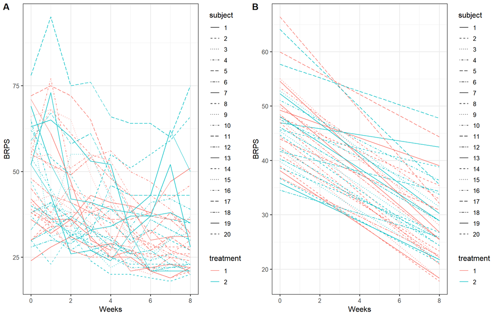

**Figure 5: A)** Base values **B)** Fitted values

```r
# draw the plot of RATSL with the observed Weight values
p1 <- ggplot(BPRS, aes(x = week, y = bprs, colour=treatment)) +
  geom_line(aes(linetype = subject)) +
  scale_linetype_manual(values = rep(1:20, times=2)) +
  scale_x_continuous(name = "Weeks") +
  scale_y_continuous(name = "BRPS") +
  theme(legend.position = "top") +
  theme_bw(12)

# Create a vector of the fitted values
Fitted <- fitted(bprs_ref2)

# Create a new column fitted to RATSL
BPRS$fitted <- Fitted

# draw the plot of RATSL with the Fitted values of weight
p2 <- ggplot(BPRS, aes(x = week, y = fitted, colour=treatment)) +
  geom_line(aes(linetype = subject)) +
  scale_linetype_manual(values = rep(1:20, times=2)) +
  scale_x_continuous(name = "Weeks") +
  scale_y_continuous(name = "BRPS") +
  theme(legend.position = "top") +
  theme_bw(12)

# Combine plots
ggarrange(p1,p2, labels = "AUTO", widths = c(1,1), nrow = 1)
```

When we compare **Figure 5A&B** we can see that the trends that we estimated by eye in this case held true. The values indeed predict the observed data and show that accros the treatment weeks both treatments decrease (or neither affects in anyway?) BRPS.